# 1. A) Read all the 3 CSV files as DataFrame and store them into 3 separate variables.

```python
#importing all the necessary mathematical, data handling & visulaization libraries
import numpy as np
import pandas as pd
import matplotlib.pyplot as plt
%matplotlib inline
import seaborn as sns
sns.set_theme(style="whitegrid")
import scipy.stats as stats
from sklearn.preprocessing import MinMaxScaler, StandardScaler
pd.set_option('display.max_rows', None)
from sklearn.model_selection import train_test_split
from sklearn.metrics import classification_report, confusion_matrix
from scipy.stats import zscore
```

```python
df_normal = pd.read_csv('Normal.csv')                                        #Answer
df_type_s = pd.read_csv('Type_S.csv')
df_type_h = pd.read_csv('Type_H.csv')
```

# 1. B) Print Shape and columns of all the 3 DataFrames

```python
print(df_normal.shape)                                                        #Answer
print(df_type_s.shape)
print(df_type_h.shape)
print('\n')
print(df_normal.columns)                                                     #Answer
print(df_type_s.columns)
print(df_type_h.columns)
```

```
(100, 7)
(150, 7)
(60, 7)


Index(['P_incidence', 'P_tilt', 'L_angle', 'S_slope', 'P_radius', 'S_Degree',
       'Class'],
      dtype='object')
Index(['P_incidence', 'P_tilt', 'L_angle', 'S_slope', 'P_radius', 'S_Degree',
       'Class'],
      dtype='object')
Index(['P_incidence', 'P_tilt', 'L_angle', 'S_slope', 'P_radius', 'S_Degree',
       'Class'],
      dtype='object')
```

# 1. C) Compare Column names of all the 3 DataFrames and clearly write observations

```python
df_normal.describe()
```

|  | P_incidence | P_tilt | L_angle | S_slope | P_radius | S_Degree |
| --- | --- | --- | --- | --- | --- | --- |
| count | 100.000000 | 100.000000 | 100.000000 | 100.000000 | 100.000000 | 100.000000 |
| mean | 51.685244 | 12.821414 | 43.542605 | 38.863830 | 123.890834 | 2.186572 |
| std | 12.368161 | 6.778503 | 12.361388 | 9.624004 | 9.014246 | 6.307483 |
| min | 30.741938 | -5.845994 | 19.071075 | 17.386972 | 100.501192 | -11.058179 |
| 25% | 42.817849 | 8.799951 | 35.000000 | 32.340487 | 118.182659 | -1.511360 |
| 50% | 50.123115 | 13.482435 | 42.638923 | 37.059694 | 123.874328 | 1.152710 |
| 75% | 61.470097 | 16.785953 | 51.602346 | 44.608788 | 129.040401 | 4.968807 |
| max | 89.834676 | 29.894119 | 90.563461 | 67.195460 | 147.894637 | 31.172767 |

```python
df_type_s.describe()
```

|  | P_incidence | P_tilt | L_angle | S_slope | P_radius | S_Degree |
| --- | --- | --- | --- | --- | --- | --- |
| count | 150.000000 | 150.000000 | 150.000000 | 150.000000 | 150.000000 | 150.000000 |
| mean | 71.514224 | 20.748038 | 64.110108 | 50.766186 | 114.518810 | 51.896687 |
| std | 15.109337 | 11.506169 | 16.397068 | 12.318813 | 15.579995 | 40.108030 |
| min | 37.903910 | -6.554948 | 24.710274 | 19.290046 | 70.082575 | 1.010041 |
| 25% | 60.658136 | 13.461149 | 52.000000 | 43.166815 | 104.706761 | 30.393271 |
| 50% | 72.149306 | 19.309548 | 62.555200 | 50.751695 | 114.842400 | 42.372509 |
| 75% | 81.075893 | 29.229680 | 76.990924 | 56.675435 | 123.337307 | 61.894425 |
| max | 129.834041 | 49.431864 | 125.742385 | 121.429566 | 163.071041 | 418.543082 |

```python
df_type_h.describe()
```

|  | P_incidence | P_tilt | L_angle | S_slope | P_radius | S_Degree |
| --- | --- | --- | --- | --- | --- | --- |
| count | 60.000000 | 60.000000 | 60.000000 | 60.000000 | 60.000000 | 60.000000 |
| mean | 47.638407 | 17.398795 | 35.463524 | 30.239612 | 116.474968 | 2.480251 |
| std | 10.697131 | 7.016708 | 9.767795 | 7.555388 | 9.355720 | 5.531177 |
| min | 26.147921 | 3.144669 | 14.000000 | 13.366931 | 84.241415 | -10.675871 |
| 25% | 41.018099 | 12.874329 | 29.038069 | 25.215275 | 112.280320 | -0.910819 |
| 50% | 46.416169 | 16.949285 | 35.164873 | 30.000659 | 116.696146 | 2.542441 |
| 75% | 53.922329 | 22.002980 | 42.011563 | 34.962103 | 122.042999 | 6.059666 |
| max | 74.433593 | 41.557331 | 62.275275 | 46.613539 | 137.540613 | 15.779697 |

```python
#Answer
print('All columns are same for all 3 dataframes but the desriptive values for each class data is different in all 3 datframes')
```

```
All columns are same for all 3 dataframes but the desriptive values for each class data is different in all 3 datframes
```

# 1. D) Print DataTypes of all the 3 DataFrames

```python
print(df_normal.dtypes)                                                              #Answer
print('\n')
print(df_type_s.dtypes)
print('\n')
print(df_type_h.dtypes)
```

```
P_incidence    float64
P_tilt         float64
L_angle        float64
S_slope        float64
P_radius       float64
S_Degree       float64
Class           object
dtype: object


P_incidence    float64
P_tilt         float64
L_angle        float64
S_slope        float64
P_radius       float64
S_Degree       float64
Class           object
dtype: object


P_incidence    float64
P_tilt         float64
L_angle        float64
S_slope        float64
P_radius       float64
S_Degree       float64
Class           object
dtype: object
```

# 1. E) Observe and share variation in ‘Class’ feature of all the 3 DaraFrames

```python
print('There are total 310 observations of the patients')                             #Answer
print('df_normal data CLASS feature accumulates 32.25% of all 3 data frames observations')
print('df_type_h data CLASS feature accumulates 19.35% of all 3 data frames observations')
print('df_type_s data CLASS feature accumulates 48.38% of all 3 data frames observations')
print('\n')
print('All the 3 classes of the target variabe is not equally balanced/distributed ')
```

```
There are total 310 observations of the patients
df_normal data CLASS feature accumulates 32.25% of all 3 data frames observations
df_type_h data CLASS feature accumulates 19.35% of all 3 data frames observations
df_type_s data CLASS feature accumulates 48.38% of all 3 data frames observations


All the 3 classes of the target variabe is not equally balanced/distributed
```

```python
df_normal['Class'].value_counts()
```

```
Normal    73
Nrmal     27
Name: Class, dtype: int64
```

```python
df_type_h['Class'].value_counts()                                                 #Answer
```

```
Type_H    37
type_h    23
Name: Class, dtype: int64
```

```python
df_type_s['Class'].value_counts()                                                     #Answer
```

```
Type_S    133
tp_s       17
Name: Class, dtype: int64
```

```python
#df_normal.info()
#df_normal.describe()
```

```python
#df_type_h.info()
#df_type_h.describe()
```

```python
#df_type_s.info()
#df_type_s.describe()
```

# 2. A) Unify all the variations in ‘Class’ feature for all the 3 DataFrames

```python
df_normal['Class'].value_counts()
```

```
Normal    73
Nrmal     27
Name: Class, dtype: int64
```

```python
df_normal['Class'].replace(to_replace= ['Normal','Nrmal'], value='type_normal', inplace= True )    # Answer
```

```python
df_normal['Class'].value_counts()
```

```
type_normal    100
Name: Class, dtype: int64
```

```python
df_type_h['Class'].value_counts()
```

```
Type_H    37
type_h    23
Name: Class, dtype: int64
```

```python
df_type_h['Class'].replace(to_replace= 'Type_H', value='type_h', inplace= True )    # Answer
```

```python
df_type_h['Class'].value_counts()
```

```
type_h    60
Name: Class, dtype: int64
```

```python
df_type_s['Class'].value_counts()
```

```
Type_S    133
tp_s       17
Name: Class, dtype: int64
```

```python
df_type_s['Class'].replace(to_replace= ['Type_S','tp_s'], value='type_s', inplace= True )    # Answer
```

```python
df_type_s['Class'].value_counts()
```

```
type_s    150
Name: Class, dtype: int64
```

# 2. B) Combine all the 3 DataFrames to form a single DataFrame

```python
df_final = pd.concat([df_normal, df_type_h, df_type_s], axis= 0 )  # Concating based on the rows
```

```python
df_final.shape                                                # Answer
```

```
(310, 7)
```

```python
df_final['Class'].unique()
```

```
array(['type_normal', 'type_h', 'type_s'], dtype=object)
```

```python
df_final.reset_index(inplace= True)
```

# 2. C) Print 5 random samples of this DataFrame

```python
print(df_final.sample(n=5))                                                  # Answer
```

```
     index  P_incidence     P_tilt    L_angle    S_slope    P_radius  \
160      0    74.377678  32.053104  78.772013  42.324573  143.560690
46      46    54.752520   9.752520  48.000000  45.000000  123.037999
129     29    66.879211  24.891999  49.278597  41.987212  113.477018
72      72    53.683380  13.447022  41.584297  40.236358  113.913703
83      83    48.902904   5.587589  55.500000  43.315316  137.108289

      S_Degree        Class
160  56.125906       type_s
46    8.235294  type_normal
129  -2.005892       type_h
72    2.737035  type_normal
83   19.854759  type_normal
```

# 2. D) Print Feature-wise percentage of Null values.

```python
df_final.isna().sum()   # Answer -    There are no null values in the final dataset - 0% null values in all features
```

```
index          0
P_incidence    0
P_tilt         0
L_angle        0
S_slope        0
P_radius       0
S_Degree       0
Class          0
dtype: int64
```

# 2. E) Check 5-point summary of the new DataFrame

```python
df_final.mean()                                             # Answer
```

```
index           57.725806
P_incidence     60.496653
P_tilt          17.542822
L_angle         51.930930
S_slope         42.953831
P_radius       117.920655
S_Degree        26.296694
dtype: float64
```

```python
df_final.median()
```

```
index           51.000000
P_incidence     58.691038
P_tilt          16.357689
L_angle         49.562398
S_slope         42.404912
P_radius       118.268178
S_Degree        11.767934
dtype: float64
```

```python
df_final.max()
```

```
index              149
P_incidence    129.834
P_tilt         49.4319
L_angle        125.742
S_slope         121.43
P_radius       163.071
S_Degree       418.543
Class           type_s
dtype: object
```

```python
df_final.min()
```

```
index                0
P_incidence    26.1479
P_tilt        -6.55495
L_angle             14
S_slope        13.3669
P_radius       70.0826
S_Degree      -11.0582
Class           type_h
dtype: object
```

```python
df_final.std()
```

```
index          39.385724
P_incidence    17.236520
P_tilt         10.008330
L_angle        18.554064
S_slope        13.423102
P_radius       13.317377
S_Degree       37.559027
dtype: float64
```

```python
# We can also directly use the describe function to get 5 point summary at once               #Answer
df_final.describe().T
```

|  | count | mean | std | min | 25% | 50% | 75% | max |
| --- | --- | --- | --- | --- | --- | --- | --- | --- |
| index | 310.0 | 57.725806 | 39.385724 | 0.000000 | 25.250000 | 51.000000 | 85.750000 | 149.000000 |
| P_incidence | 310.0 | 60.496653 | 17.236520 | 26.147921 | 46.430294 | 58.691038 | 72.877696 | 129.834041 |
| P_tilt | 310.0 | 17.542822 | 10.008330 | -6.554948 | 10.667069 | 16.357689 | 22.120395 | 49.431864 |
| L_angle | 310.0 | 51.930930 | 18.554064 | 14.000000 | 37.000000 | 49.562398 | 63.000000 | 125.742385 |
| S_slope | 310.0 | 42.953831 | 13.423102 | 13.366931 | 33.347122 | 42.404912 | 52.695888 | 121.429566 |
| P_radius | 310.0 | 117.920655 | 13.317377 | 70.082575 | 110.709196 | 118.268178 | 125.467674 | 163.071041 |
| S_Degree | 310.0 | 26.296694 | 37.559027 | -11.058179 | 1.603727 | 11.767934 | 41.287352 | 418.543082 |

# 3. A) Visualize a heatmap to understand correlation between all features

```python
df_final_features = df_final.drop('Class', axis= 1)
```

```python
df_final_features.head(2)
```

|  | index | P_incidence | P_tilt | L_angle | S_slope | P_radius | S_Degree |
| --- | --- | --- | --- | --- | --- | --- | --- |
| 0 | 0 | 38.505273 | 16.964297 | 35.112814 | 21.540976 | 127.632875 | 7.986683 |
| 1 | 1 | 54.920858 | 18.968430 | 51.601455 | 35.952428 | 125.846646 | 2.001642 |

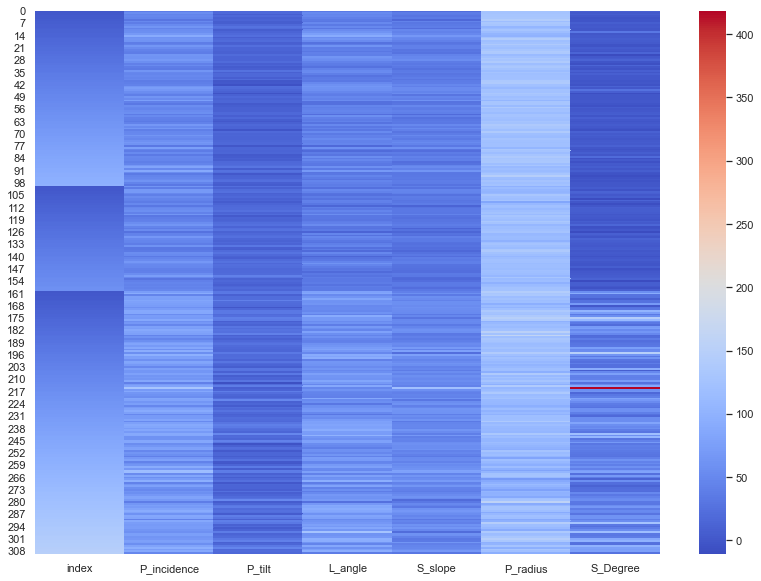

```python
plt.figure(figsize = (14,10))                                                                  #Answer
sns.heatmap(data= df_final_features, annot= False, linecolor= 'black', cmap= 'coolwarm')
```

```python
df_final.corr()
```

|  | index | P_incidence | P_tilt | L_angle | S_slope | P_radius | S_Degree |
| --- | --- | --- | --- | --- | --- | --- | --- |
| index | 1.000000 | 0.253943 | 0.088791 | 0.333948 | 0.259884 | -0.245724 | 0.260775 |
| P_incidence | 0.253943 | 1.000000 | 0.629199 | 0.717282 | 0.814960 | -0.247467 | 0.638743 |
| P_tilt | 0.088791 | 0.629199 | 1.000000 | 0.432764 | 0.062345 | 0.032668 | 0.397862 |
| L_angle | 0.333948 | 0.717282 | 0.432764 | 1.000000 | 0.598387 | -0.080344 | 0.533667 |
| S_slope | 0.259884 | 0.814960 | 0.062345 | 0.598387 | 1.000000 | -0.342128 | 0.523557 |
| P_radius | -0.245724 | -0.247467 | 0.032668 | -0.080344 | -0.342128 | 1.000000 | -0.026065 |
| S_Degree | 0.260775 | 0.638743 | 0.397862 | 0.533667 | 0.523557 | -0.026065 | 1.000000 |

# 3. C) Visualize a pairplot with 3 classes distinguished by colors and share insights

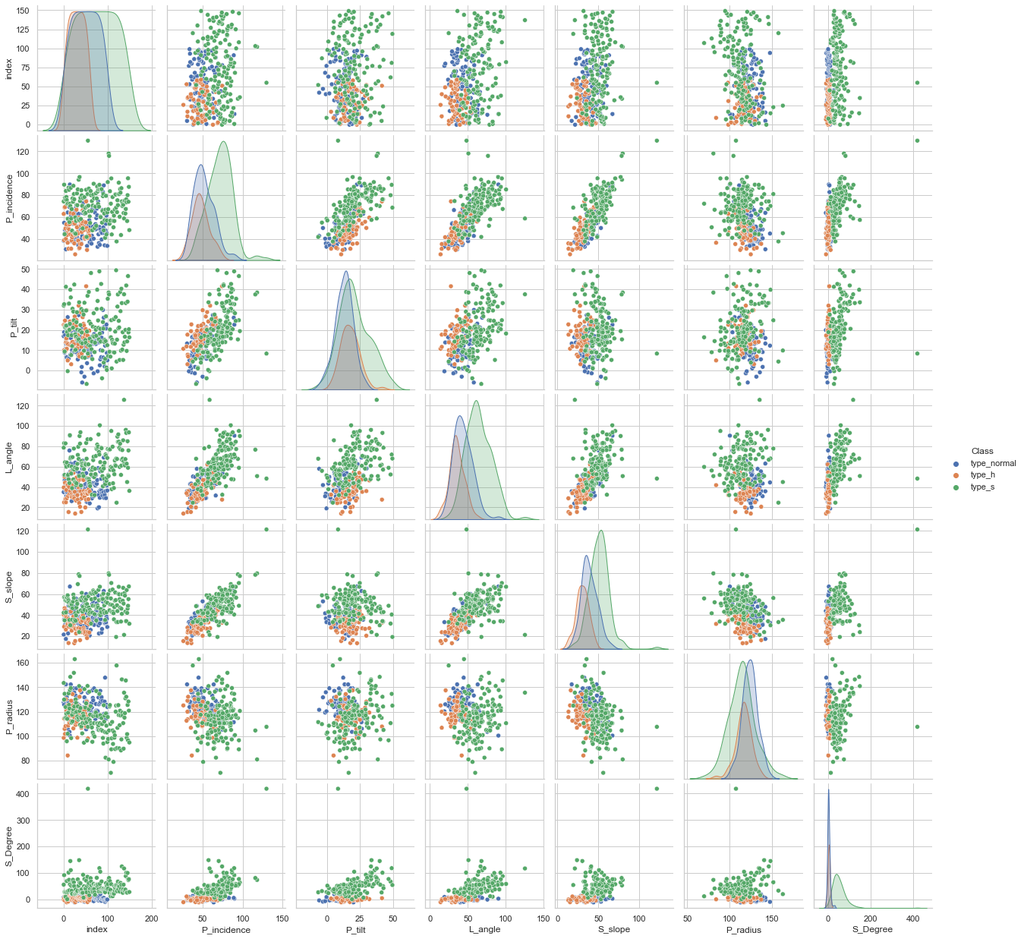

```python
sns.pairplot(df_final, hue= 'Class')                              #Answer Insights to be observed here
```

```python
print('L_angle feature is slightly highly linealry correlated with s_slope feature')
print('L_angle feature is slightly highly linealry correlated with s_degree feature')
print('P_incidence feature is slightly linealry correlated with s_slope feature')
print('P_tilt feature is the least correlated with P_radius feature as all the datapoints of all 3 classes are randomly scattered')
print('Type_s class has few outliers in S_degree feature')
```

```
L_angle feature is slightly highly linealry correlated with s_slope feature
L_angle feature is slightly highly linealry correlated with s_degree feature
P_incidence feature is slightly linealry correlated with s_slope feature
P_tilt feature is the least correlated with P_radius feature as all the datapoints of all 3 classes are randomly scattered
Type_s class has few outliers in S_degree feature
```

# 3. D) Visualize a jointplot for ‘P_incidence’ and ‘S_slope’ and share insights

```python
df_final.head()
```

|  | index | P_incidence | P_tilt | L_angle | S_slope | P_radius | S_Degree | Class |
| --- | --- | --- | --- | --- | --- | --- | --- | --- |
| 0 | 0 | 38.505273 | 16.964297 | 35.112814 | 21.540976 | 127.632875 | 7.986683 | type_normal |
| 1 | 1 | 54.920858 | 18.968430 | 51.601455 | 35.952428 | 125.846646 | 2.001642 | type_normal |
| 2 | 2 | 44.362490 | 8.945435 | 46.902096 | 35.417055 | 129.220682 | 4.994195 | type_normal |
| 3 | 3 | 48.318931 | 17.452121 | 48.000000 | 30.866809 | 128.980308 | -0.910941 | type_normal |
| 4 | 4 | 45.701789 | 10.659859 | 42.577846 | 35.041929 | 130.178314 | -3.388910 | type_normal |

```
 The values of P_incidence and S_slope are almost linearly correlated
```

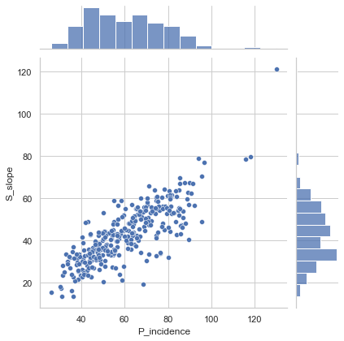

```python
sns.jointplot(data= df_final, x= df_final['P_incidence'], y= df_final['S_slope']) # Answer
print(' The values of P_incidence and S_slope are almost linearly correlated')
```

# 3. E) Visualize a boxplot to check distribution of the features and share insights

```
The "P_incidence" feature seems to be normally distributed with some outliers within 110 - 140
```

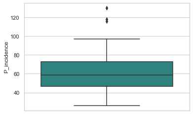

```python
sns.boxplot(data= df_final,  y= df_final['P_incidence'], palette= 'viridis')             #Answer
print('The "P_incidence" feature seems to be normally distributed with some outliers within 110 - 140')
```

```
The "P_tilt" feature seems to be slightly normally distributed with some outliers within 40 - 50 near to the maximum whisker value
```

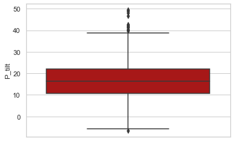

```python
sns.boxplot(data= df_final,  y= df_final['P_tilt'], palette= 'gist_heat_r')                     #Answer
print('The "P_tilt" feature seems to be slightly normally distributed with some outliers within 40 - 50 near to the maximum whisker value')
```

```
The "P_radius" feature seems to be slightly normally distributed with some outliers out of the + or - 1.5 IQR  or max & min values
```

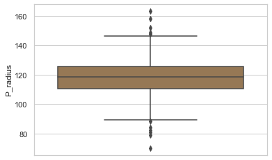

```python
sns.boxplot(data= df_final,  y= df_final['P_radius'], palette= 'cubehelix')                           #Answer
print('The "P_radius" feature seems to be slightly normally distributed with some outliers out of the + or - 1.5 IQR  or max & min values')
```

```
The "L_angle" feature seems to be slightly right skewed distributed with only 1 outlier outside + 1.5 IQR range or max value
```

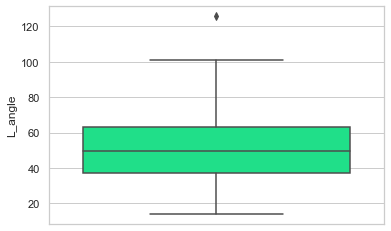

```python
sns.boxplot(data= df_final,  y= df_final['L_angle'], palette= 'gist_rainbow')                     #Answer
print('The "L_angle" feature seems to be slightly right skewed distributed with only 1 outlier outside + 1.5 IQR range or max value')
```

```
The "S_slope" feature seems to be slightly normally distributed with 1 high outlier far away of the + or - 1.5 IQR  or max & min values
```

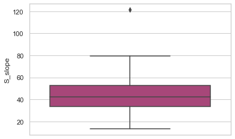

```python
sns.boxplot(data= df_final,  y= df_final['S_slope'], palette= 'magma')                           #Answer
print('The "S_slope" feature seems to be slightly normally distributed with 1 high outlier far away of the + or - 1.5 IQR  or max & min values')
```

[output not shown]

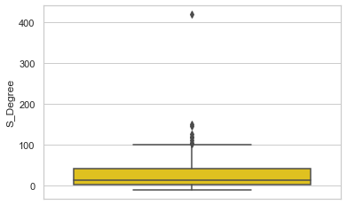

```python
sns.boxplot(data= df_final,  y= df_final['S_Degree'], palette= 'prism')                         #Answer
print('The "P_radius" feature seems to be right skewed distributed with many outliers out of the + or - 1.5 IQR  or max & min values close to the max value and 1 outlier very far')
```

# 4. A) Split data into X and Y.

```python
X = df_final.drop(labels= 'Class', axis=1)
y = df_final['Class']
```

```python
X.head()
```

|  | index | P_incidence | P_tilt | L_angle | S_slope | P_radius | S_Degree |
| --- | --- | --- | --- | --- | --- | --- | --- |
| 0 | 0 | 38.505273 | 16.964297 | 35.112814 | 21.540976 | 127.632875 | 7.986683 |
| 1 | 1 | 54.920858 | 18.968430 | 51.601455 | 35.952428 | 125.846646 | 2.001642 |
| 2 | 2 | 44.362490 | 8.945435 | 46.902096 | 35.417055 | 129.220682 | 4.994195 |
| 3 | 3 | 48.318931 | 17.452121 | 48.000000 | 30.866809 | 128.980308 | -0.910941 |
| 4 | 4 | 45.701789 | 10.659859 | 42.577846 | 35.041929 | 130.178314 | -3.388910 |

```python
y.head()
```

```
0    type_normal
1    type_normal
2    type_normal
3    type_normal
4    type_normal
Name: Class, dtype: object
```

```python
df_final.info()
```

```
<class 'pandas.core.frame.DataFrame'>
RangeIndex: 310 entries, 0 to 309
Data columns (total 8 columns):
 #   Column       Non-Null Count  Dtype
---  ------       --------------  -----
 0   index        310 non-null    int64
 1   P_incidence  310 non-null    float64
 2   P_tilt       310 non-null    float64
 3   L_angle      310 non-null    float64
 4   S_slope      310 non-null    float64
 5   P_radius     310 non-null    float64
 6   S_Degree     310 non-null    float64
 7   Class        310 non-null    object
dtypes: float64(6), int64(1), object(1)
memory usage: 19.5+ KB
```

```python
# We will convert the  features data X as we do not know any information about those features like units
X_scaled = X.apply(zscore)
```

```python
X_scaled.head()
```

|  | index | P_incidence | P_tilt | L_angle | S_slope | P_radius | S_Degree |
| --- | --- | --- | --- | --- | --- | --- | --- |
| 0 | -1.468023 | -1.277922 | -0.057898 | -0.907904 | -1.597803 | 0.730468 | -0.488288 |
| 1 | -1.442592 | -0.324010 | 0.142672 | -0.017786 | -0.522437 | 0.596124 | -0.647896 |
| 2 | -1.417161 | -0.937559 | -0.860412 | -0.271475 | -0.562386 | 0.849889 | -0.568091 |
| 3 | -1.391730 | -0.707649 | -0.009077 | -0.212206 | -0.901920 | 0.831811 | -0.725568 |
| 4 | -1.366299 | -0.859732 | -0.688835 | -0.504914 | -0.590377 | 0.921914 | -0.791650 |

# 4. B) Split data into train and test with 80:20 proportion

```python
X_train, X_test, y_train, y_test = train_test_split(X_scaled, y, test_size= 0.20, random_state= 1 )         #Answer
```

```python
print(X_train.shape)
print(X_test.shape)
print(y_train.shape)
print(y_test.shape)
```

```
(248, 7)
(62, 7)
(248,)
(62,)
```

# 4. C) Train a Supervised Learning Classification base model using KNN classifier

```python
knn = KNeighborsClassifier(n_neighbors= 5 , weights = 'distance' )    # Instantiating the model
```

```python
knn.fit(X_train, y_train)                                              # Fitting the model              # Answer
```

```
KNeighborsClassifier(weights='distance')
```

```python
predictions = knn.predict(X_test)                                      # predicting the data
```

```python
predictions.shape
```

```
(62,)
```

# 4. D) Print all the possible performance metrics for both train and test data

```python
print(knn.score(X_test, y_test))        # test data 75 %
print('\n')
print(knn.score(X_train, y_train))       # train data 100 %
```

```
0.7580645161290323


1.0
```

```python
print(confusion_matrix(y_test, predictions))                                                #Answer
print('\n')
print(classification_report(y_test, predictions))
```

```
[[ 9  2  0]
 [ 3 11  4]
 [ 3  3 27]]


              precision    recall  f1-score   support

      type_h       0.60      0.82      0.69        11
 type_normal       0.69      0.61      0.65        18
      type_s       0.87      0.82      0.84        33

    accuracy                           0.76        62
   macro avg       0.72      0.75      0.73        62
weighted avg       0.77      0.76      0.76        62
```

# 5. A) Experiment with various parameters to improve performance of the base model.

```python
accuracy_scores = []
```

```python
for k in range(1,50):                                                                    #Answer
    knn_classifier = KNeighborsClassifier(n_neighbors= k, weights= 'distance' )
    knn_classifier.fit(X_train, y_train)
    accuracy_scores.append(knn_classifier.score(X_test, y_test))
```

```python
max(accuracy_scores)
```

```
0.7903225806451613
```

```python
accuracy_scores
```

```
[0.7903225806451613,
 0.7903225806451613,
 0.7580645161290323,
 0.7741935483870968,
 0.7580645161290323,
 0.7580645161290323,
 0.7580645161290323,
 0.7741935483870968,
 0.7741935483870968,
 0.7741935483870968,
 0.7741935483870968,
 0.7741935483870968,
 0.7741935483870968,
 0.7741935483870968,
 0.7741935483870968,
 0.7741935483870968,
 0.7903225806451613,
 0.7903225806451613,
 0.7903225806451613,
 0.7741935483870968,
 0.7741935483870968,
 0.7741935483870968,
 0.7741935483870968,
 0.7741935483870968,
 0.7741935483870968,
 0.7741935483870968,
 0.7903225806451613,
 0.7903225806451613,
 0.7903225806451613,
 0.7903225806451613,
 0.7903225806451613,
 0.7903225806451613,
 0.7903225806451613,
 0.7903225806451613,
 0.7741935483870968,
 0.7741935483870968,
 0.7741935483870968,
 0.7741935483870968,
 0.7741935483870968,
 0.7741935483870968,
 0.7741935483870968,
 0.7741935483870968,
 0.7741935483870968,
 0.7741935483870968,
 0.7741935483870968,
 0.7741935483870968,
 0.7741935483870968,
 0.7903225806451613,
 0.7903225806451613]
```

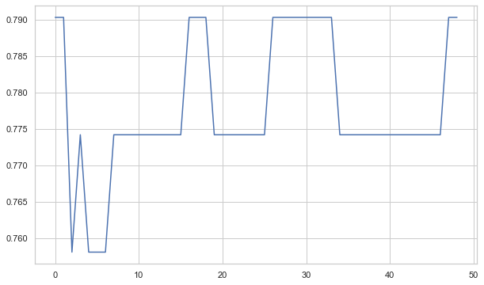

```python
plt.figure(figsize=(10,6))
plt.plot(accuracy_scores)
```

# Trying to evaluate the new performance with new value k = 17

```python
# Let's try K= 17 and see the metrics
knn_17 = KNeighborsClassifier(n_neighbors= 17 , weights = 'distance' )    # Instantiating the model
```

```python
knn_17.fit(X_train, y_train)                                              # Fitting the data
```

```
KNeighborsClassifier(n_neighbors=17, weights='distance')
```

```python
predictions_17 = knn_17.predict(X_test)                                    # Predicting
```

```python
print(confusion_matrix(y_test, predictions_17))                           # Metrics               #Answer
print('\n')
print(classification_report(y_test, predictions_17))
print('\n')
print(' With using K value as 17 we got +3 % in Accuracy and +4 % in Precision, 5% in Recall')
```

```
[[10  1  0]
 [ 3 12  3]
 [ 1  5 27]]


              precision    recall  f1-score   support

      type_h       0.71      0.91      0.80        11
 type_normal       0.67      0.67      0.67        18
      type_s       0.90      0.82      0.86        33

    accuracy                           0.79        62
   macro avg       0.76      0.80      0.77        62
weighted avg       0.80      0.79      0.79        62



 With using K value as 17 we got +3 % in Accuracy and +4 % in Precision, 5% in Recall
```

# 5. B) Clearly showcase improvement in performance achieved

# We will use GridSearch CV method to performance variation using various paramters

```python
# After researching we need to use different hyper parameters like P, leaf_size and K (which is the neighbour)
#Hyperparameters that we want to tune.
from sklearn.model_selection import GridSearchCV
leaf_size = list(range(1,50))
no_of_neighbors = list(range(1,50))
P = [1,2]
```

```python
#Convert to dictionary
hyperparameters = dict(leaf_size=leaf_size, n_neighbors= no_of_neighbors, p= P)
```

```python
#hyperparameters
```

```python
#Create new KNN object
knn_tuning = KNeighborsClassifier()
```

```python
#Use GridSearch using cross validation
GS_classifier = GridSearchCV(knn_tuning, hyperparameters, cv= 5)
```

```python
#Fit the model
best_model = GS_classifier.fit(X_train,y_train)
```

```python
df_best_model_results = pd.DataFrame(best_model.cv_results_)
```

```python
df_best_model_results.head()
```

|  | mean_fit_time | std_fit_time | mean_score_time | std_score_time | param_leaf_size | param_n_neighbors | param_p | params | split0_test_score | split1_test_score | split2_test_score | split3_test_score | split4_test_score | mean_test_score | std_test_score | rank_test_score |
| --- | --- | --- | --- | --- | --- | --- | --- | --- | --- | --- | --- | --- | --- | --- | --- | --- |
| 0 | 0.004401 | 0.002331 | 0.008529 | 0.006145 | 1 | 1 | 1 | {'leaf_size': 1, 'n_neighbors': 1, 'p': 1} | 0.70 | 0.86 | 0.80 | 0.816327 | 0.795918 | 0.794449 | 0.052401 | 4558 |
| 1 | 0.004729 | 0.005745 | 0.004331 | 0.005839 | 1 | 1 | 2 | {'leaf_size': 1, 'n_neighbors': 1, 'p': 2} | 0.74 | 0.80 | 0.78 | 0.816327 | 0.734694 | 0.774204 | 0.032262 | 4754 |
| 2 | 0.003125 | 0.006249 | 0.003125 | 0.006249 | 1 | 2 | 1 | {'leaf_size': 1, 'n_neighbors': 2, 'p': 1} | 0.76 | 0.88 | 0.80 | 0.836735 | 0.775510 | 0.810449 | 0.043367 | 4068 |
| 3 | 0.004964 | 0.006410 | 0.007249 | 0.007077 | 1 | 2 | 2 | {'leaf_size': 1, 'n_neighbors': 2, 'p': 2} | 0.76 | 0.82 | 0.80 | 0.795918 | 0.795918 | 0.794367 | 0.019363 | 4607 |
| 4 | 0.005720 | 0.005242 | 0.002423 | 0.002066 | 1 | 3 | 1 | {'leaf_size': 1, 'n_neighbors': 3, 'p': 1} | 0.74 | 0.84 | 0.84 | 0.857143 | 0.877551 | 0.830939 | 0.047526 | 2549 |

```python
df_best_model_results[['param_leaf_size','param_n_neighbors','param_p','params','mean_test_score']]
```

|  | param_leaf_size | param_n_neighbors | param_p | params | mean_test_score |
| --- | --- | --- | --- | --- | --- |
| 0 | 1 | 1 | 1 | {'leaf_size': 1, 'n_neighbors': 1, 'p': 1} | 0.794449 |
| 1 | 1 | 1 | 2 | {'leaf_size': 1, 'n_neighbors': 1, 'p': 2} | 0.774204 |
| 2 | 1 | 2 | 1 | {'leaf_size': 1, 'n_neighbors': 2, 'p': 1} | 0.810449 |
| 3 | 1 | 2 | 2 | {'leaf_size': 1, 'n_neighbors': 2, 'p': 2} | 0.794367 |
| 4 | 1 | 3 | 1 | {'leaf_size': 1, 'n_neighbors': 3, 'p': 1} | 0.830939 |
| 5 | 1 | 3 | 2 | {'leaf_size': 1, 'n_neighbors': 3, 'p': 2} | 0.802449 |
| 6 | 1 | 4 | 1 | {'leaf_size': 1, 'n_neighbors': 4, 'p': 1} | 0.798204 |
| 7 | 1 | 4 | 2 | {'leaf_size': 1, 'n_neighbors': 4, 'p': 2} | 0.802367 |
| 8 | 1 | 5 | 1 | {'leaf_size': 1, 'n_neighbors': 5, 'p': 1} | 0.818449 |
| 9 | 1 | 5 | 2 | {'leaf_size': 1, 'n_neighbors': 5, 'p': 2} | 0.814694 |
| 10 | 1 | 6 | 1 | {'leaf_size': 1, 'n_neighbors': 6, 'p': 1} | 0.802286 |
| 11 | 1 | 6 | 2 | {'leaf_size': 1, 'n_neighbors': 6, 'p': 2} | 0.818449 |
| 12 | 1 | 7 | 1 | {'leaf_size': 1, 'n_neighbors': 7, 'p': 1} | 0.826612 |
| 13 | 1 | 7 | 2 | {'leaf_size': 1, 'n_neighbors': 7, 'p': 2} | 0.818694 |
| 14 | 1 | 8 | 1 | {'leaf_size': 1, 'n_neighbors': 8, 'p': 1} | 0.834694 |
| 15 | 1 | 8 | 2 | {'leaf_size': 1, 'n_neighbors': 8, 'p': 2} | 0.830531 |
| 16 | 1 | 9 | 1 | {'leaf_size': 1, 'n_neighbors': 9, 'p': 1} | 0.826531 |
| 17 | 1 | 9 | 2 | {'leaf_size': 1, 'n_neighbors': 9, 'p': 2} | 0.830449 |
| 18 | 1 | 10 | 1 | {'leaf_size': 1, 'n_neighbors': 10, 'p': 1} | 0.850857 |
| 19 | 1 | 10 | 2 | {'leaf_size': 1, 'n_neighbors': 10, 'p': 2} | 0.838531 |
| 20 | 1 | 11 | 1 | {'leaf_size': 1, 'n_neighbors': 11, 'p': 1} | 0.818612 |
| 21 | 1 | 11 | 2 | {'leaf_size': 1, 'n_neighbors': 11, 'p': 2} | 0.838449 |
| 22 | 1 | 12 | 1 | {'leaf_size': 1, 'n_neighbors': 12, 'p': 1} | 0.834531 |
| 23 | 1 | 12 | 2 | {'leaf_size': 1, 'n_neighbors': 12, 'p': 2} | 0.834531 |
| 24 | 1 | 13 | 1 | {'leaf_size': 1, 'n_neighbors': 13, 'p': 1} | 0.814367 |
| 25 | 1 | 13 | 2 | {'leaf_size': 1, 'n_neighbors': 13, 'p': 2} | 0.842857 |
| 26 | 1 | 14 | 1 | {'leaf_size': 1, 'n_neighbors': 14, 'p': 1} | 0.838694 |
| 27 | 1 | 14 | 2 | {'leaf_size': 1, 'n_neighbors': 14, 'p': 2} | 0.863020 |
| 28 | 1 | 15 | 1 | {'leaf_size': 1, 'n_neighbors': 15, 'p': 1} | 0.838694 |
| 29 | 1 | 15 | 2 | {'leaf_size': 1, 'n_neighbors': 15, 'p': 2} | 0.838612 |

[output cut: 4772 more lines]

```python
print(best_model.best_estimator_)
print('\n')
print(best_model.get_params)
print('\n')
print(best_model.best_score_)
```

```
KNeighborsClassifier(leaf_size=1, n_neighbors=14)


<bound method BaseEstimator.get_params of GridSearchCV(cv=5, estimator=KNeighborsClassifier(),
             param_grid={'leaf_size': [1, 2, 3, 4, 5, 6, 7, 8, 9, 10, 11, 12,
                                       13, 14, 15, 16, 17, 18, 19, 20, 21, 22,
                                       23, 24, 25, 26, 27, 28, 29, 30, ...],
                         'n_neighbors': [1, 2, 3, 4, 5, 6, 7, 8, 9, 10, 11, 12,
                                         13, 14, 15, 16, 17, 18, 19, 20, 21, 22,
                                         23, 24, 25, 26, 27, 28, 29, 30, ...],
                         'p': [1, 2]})>


0.8630204081632653
```

# Now we will use the new parameters n_neighbors, p and leaf_size to test the model metrics - leaf_size = 1, n_neighbors = 14, p = 2 as the model best test score for these values

```python
# Let's try K= 48, leaf_size =1, p= 2 and see the metrics
knn_14_1_2 = KNeighborsClassifier(n_neighbors= 14, leaf_size= 1,  p= 2, weights = 'distance' )
```

```python
knn_14_1_2.fit(X_train, y_train)
```

```
KNeighborsClassifier(leaf_size=1, n_neighbors=14, weights='distance')
```

```python
predictions_14_1_2 = knn_14_1_2.predict(X_test)
```

```python
print(confusion_matrix(y_test, predictions_14_1_2))                           # Metrics
print('\n')
print(classification_report(y_test, predictions_14_1_2))
print('\n')
print(' using GridSearch by changing parameters  we got +2 % in accuracy and +2 % in precision')
```

```
[[ 9  2  0]
 [ 3 12  3]
 [ 1  5 27]]


              precision    recall  f1-score   support

      type_h       0.69      0.82      0.75        11
 type_normal       0.63      0.67      0.65        18
      type_s       0.90      0.82      0.86        33

    accuracy                           0.77        62
   macro avg       0.74      0.77      0.75        62
weighted avg       0.79      0.77      0.78        62



 using GridSearch by changing parameters  we got +2 % in accuracy and +2 % in precision
```

# 5. C) Clearly state which parameters contributed most to improve model performance

```python
print('It is clearly seen that n_neighbors and leaf_sise contribute for change in accuracy and precision')
```

```
It is clearly seen that n_neighbors and leaf_sise contribute for change in accuracy and precision
```

```python
print('******************************* END OF PART A ****************************************')
```

```
******************************* END OF PART A ****************************************
```

# 1. A) Read both the Datasets ‘Data1’ and ‘Data 2’ as DataFrame and store them into two separate variables

```python
mk_df2 = pd.read_csv('Part2+-Data2.csv')                                  #Answer
mk_df1 = pd.read_csv('Part2+-+Data1.csv')
```

# 1. B) Print shape and Column Names and DataTypes of both the Dataframes

```python
print('******DATAFRAME 1******')                                             # Answer
print('\n')
print(mk_df1.columns)
print('\n')
print(mk_df1.shape)
print('\n')
print(mk_df1.dtypes)
print('\n')
print('******DATAFRAME 2******')
print('\n')
print(mk_df2.columns)
print('\n')
print(mk_df2.shape)
print('\n')
print(mk_df2.dtypes)
```

```
******DATAFRAME 1******


Index(['ID', 'Age', 'CustomerSince', 'HighestSpend', 'ZipCode', 'HiddenScore',
       'MonthlyAverageSpend', 'Level'],
      dtype='object')


(5000, 8)


ID                       int64
Age                      int64
CustomerSince            int64
HighestSpend             int64
ZipCode                  int64
HiddenScore              int64
MonthlyAverageSpend    float64
Level                    int64
dtype: object


******DATAFRAME 2******


Index(['ID', 'Mortgage', 'Security', 'FixedDepositAccount', 'InternetBanking',
       'CreditCard', 'LoanOnCard'],
      dtype='object')


(5000, 7)


ID                       int64
Mortgage                 int64
Security                 int64
FixedDepositAccount      int64
InternetBanking          int64
CreditCard               int64
LoanOnCard             float64
dtype: object
```

```python
mk_df1.info()
```

```
<class 'pandas.core.frame.DataFrame'>
RangeIndex: 5000 entries, 0 to 4999
Data columns (total 8 columns):
 #   Column               Non-Null Count  Dtype
---  ------               --------------  -----
 0   ID                   5000 non-null   int64
 1   Age                  5000 non-null   int64
 2   CustomerSince        5000 non-null   int64
 3   HighestSpend         5000 non-null   int64
 4   ZipCode              5000 non-null   int64
 5   HiddenScore          5000 non-null   int64
 6   MonthlyAverageSpend  5000 non-null   float64
 7   Level                5000 non-null   int64
dtypes: float64(1), int64(7)
memory usage: 312.6 KB
```

```python
mk_df2.info()
```

```
<class 'pandas.core.frame.DataFrame'>
RangeIndex: 5000 entries, 0 to 4999
Data columns (total 7 columns):
 #   Column               Non-Null Count  Dtype
---  ------               --------------  -----
 0   ID                   5000 non-null   int64
 1   Mortgage             5000 non-null   int64
 2   Security             5000 non-null   int64
 3   FixedDepositAccount  5000 non-null   int64
 4   InternetBanking      5000 non-null   int64
 5   CreditCard           5000 non-null   int64
 6   LoanOnCard           4980 non-null   float64
dtypes: float64(1), int64(6)
memory usage: 273.6 KB
```

# 1 . C) Merge both the Dataframes on ‘ID’ feature to form a single DataFrame

```python
mk_merged_df = pd.merge(mk_df1, mk_df2, how= 'outer', on= 'ID' )             # Answer
```

```python
mk_merged_df.info()
```

[output not shown]

```python
mk_merged_df.shape
```

```
(5000, 14)
```

```python
mk_merged_df.head(2)
```

|  | ID | Age | CustomerSince | HighestSpend | ZipCode | HiddenScore | MonthlyAverageSpend | Level | Mortgage | Security | FixedDepositAccount | InternetBanking | CreditCard | LoanOnCard |
| --- | --- | --- | --- | --- | --- | --- | --- | --- | --- | --- | --- | --- | --- | --- |
| 0 | 1 | 25 | 1 | 49 | 91107 | 4 | 1.6 | 1 | 0 | 1 | 0 | 0 | 0 | 1.0 |
| 1 | 2 | 45 | 19 | 34 | 90089 | 3 | 1.5 | 1 | 0 | 1 | 0 | 0 | 0 | 1.0 |

```python
mk_merged_df.dtypes
```

```
ID                       int64
Age                      int64
CustomerSince            int64
HighestSpend             int64
ZipCode                  int64
HiddenScore              int64
MonthlyAverageSpend    float64
Level                    int64
Mortgage                 int64
Security                 int64
FixedDepositAccount      int64
InternetBanking          int64
CreditCard               int64
LoanOnCard             float64
dtype: object
```

# 1. D) Change Datatype of below features to ‘Object’ - ‘CreditCard’, ‘InternetBanking’, ‘FixedDepositAccount’, ‘Security’, ‘Level’, ‘HiddenScore’

```python
mk_merged_df['CreditCard'] = mk_merged_df['CreditCard'].astype('object')                          # Answer
mk_merged_df['InternetBanking'] = mk_merged_df['InternetBanking'].astype('object')
mk_merged_df['FixedDepositAccount'] = mk_merged_df['FixedDepositAccount'].astype('object')
mk_merged_df['Security'] = mk_merged_df['Security'].astype('object')
mk_merged_df['Level'] = mk_merged_df['Level'].astype('object')
mk_merged_df['HiddenScore'] = mk_merged_df['HiddenScore'].astype('object')
```

```python
mk_merged_df.dtypes         # Datatype of the above columns have changed from int/float to object type
```

```
ID                       int64
Age                      int64
CustomerSince            int64
HighestSpend             int64
ZipCode                  int64
HiddenScore             object
MonthlyAverageSpend    float64
Level                   object
Mortgage                 int64
Security                object
FixedDepositAccount     object
InternetBanking         object
CreditCard              object
LoanOnCard             float64
dtype: object
```

# 2. A) Visualize distribution of Target variable ‘LoanOnCard’ and clearly share insights.

```
The data on the target variable is unevenly distributed with 0.0 value is 90.0 percentage and 1.0 value is 9.6 percentage
```

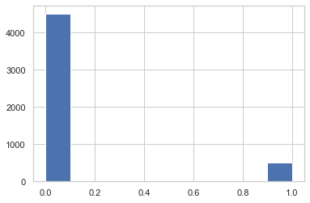

```python
mk_merged_df['LoanOnCard'].hist()
print('The data on the target variable is unevenly distributed with 0.0 value is ' + str((4500/5000)*100)
      + ' percentage and 1.0 value is ' + str((480/5000)*100) + ' percentage')
```

# 2. B) Check the percentage of missing values and impute if required

```python
mk_merged_df['LoanOnCard'].isna().sum()
```

```
20
```

```python
print('There are total 20 null values in the target variable which is ' + str((20/5000)*100) + ' percentage which is very minute')
```

```
There are total 20 null values in the target variable which is 0.4 percentage which is very minute
```

```python
mk_merged_df['LoanOnCard'].value_counts()
```

```
0.0    4500
1.0     480
Name: LoanOnCard, dtype: int64
```

```python
mk_merged_df['LoanOnCard'] = mk_merged_df['LoanOnCard'].replace(np.nan, 1)   #Here we are replacing the null values with 1 which is minority class in target variable
```

```python
mk_merged_df['LoanOnCard'].value_counts()
```

```
0.0    4500
1.0     500
Name: LoanOnCard, dtype: int64
```

# 2. C) Check for unexpected values in each categorical variable and impute with best suitable value.

```python
mk_merged_df.select_dtypes('object').columns               #Answer
```

```
Index(['HiddenScore', 'Level', 'Security', 'FixedDepositAccount',
       'InternetBanking', 'CreditCard'],
      dtype='object')
```

```python
mk_merged_df['HiddenScore'].value_counts()                  # All values are numbers and don't have any unexpected values
```

```
1    1472
2    1296
4    1222
3    1010
Name: HiddenScore, dtype: int64
```

```python
mk_merged_df['Level'].value_counts()                     # All values are numbers and don't have any unexpected values
```

```
1    2096
3    1501
2    1403
Name: Level, dtype: int64
```

```python
mk_merged_df['Security'].value_counts()                   # All values are numbers and don't have any unexpected values
```

```
0    4478
1     522
Name: Security, dtype: int64
```

```python
mk_merged_df['FixedDepositAccount'].value_counts()         # All values are numbers and don't have any unexpected values
```

```
0    4698
1     302
Name: FixedDepositAccount, dtype: int64
```

```python
mk_merged_df['InternetBanking'].value_counts()              # All values are numbers and don't have any unexpected values
```

```
1    2984
0    2016
Name: InternetBanking, dtype: int64
```

```python
mk_merged_df['CreditCard'].value_counts()                      # All values are numbers and don't have any unexpected values
```

```
0    3530
1    1470
Name: CreditCard, dtype: int64
```

```python
mk_merged_df.dtypes
```

```
ID                       int64
Age                      int64
CustomerSince            int64
HighestSpend             int64
ZipCode                  int64
HiddenScore             object
MonthlyAverageSpend    float64
Level                   object
Mortgage                 int64
Security                object
FixedDepositAccount     object
InternetBanking         object
CreditCard              object
LoanOnCard             float64
dtype: object
```

# 3. A) Split data into X and Y

```python
X2 = mk_merged_df.drop(columns= ['ID','ZipCode','LoanOnCard'], axis= 1)              #Answer    X2 and y2 because it's part B question
```

```python
X2.info()
```

```
<class 'pandas.core.frame.DataFrame'>
Int64Index: 5000 entries, 0 to 4999
Data columns (total 11 columns):
 #   Column               Non-Null Count  Dtype
---  ------               --------------  -----
 0   Age                  5000 non-null   int64
 1   CustomerSince        5000 non-null   int64
 2   HighestSpend         5000 non-null   int64
 3   HiddenScore          5000 non-null   object
 4   MonthlyAverageSpend  5000 non-null   float64
 5   Level                5000 non-null   object
 6   Mortgage             5000 non-null   int64
 7   Security             5000 non-null   object
 8   FixedDepositAccount  5000 non-null   object
 9   InternetBanking      5000 non-null   object
 10  CreditCard           5000 non-null   object
dtypes: float64(1), int64(4), object(6)
memory usage: 468.8+ KB
```

```python
scaler = StandardScaler()  # We are scaling the data as we have different large numbers and we don't know units of many columns
```

```python
scaler.fit(X2)
```

```
StandardScaler()
```

```python
scaled_features = scaler.transform(X2)
```

```python
X2_scaled = pd.DataFrame(scaled_features, columns= ['Age','CustomerSince','HighestSpend','HiddenScore','MonthlyAverageSpend',
                                        'Level','Mortgage','Security','FixedDepositAccount','InternetBanking','CreditCard'] )
```

```python
X2_scaled.head()
```

|  | Age | CustomerSince | HighestSpend | HiddenScore | MonthlyAverageSpend | Level | Mortgage | Security | FixedDepositAccount | InternetBanking | CreditCard |
| --- | --- | --- | --- | --- | --- | --- | --- | --- | --- | --- | --- |
| 0 | -1.774417 | -1.666078 | -0.538229 | 1.397414 | -0.193385 | -1.049078 | -0.555524 | 2.928915 | -0.25354 | -1.216618 | -0.645314 |
| 1 | -0.029524 | -0.096330 | -0.864109 | 0.525991 | -0.250611 | -1.049078 | -0.555524 | 2.928915 | -0.25354 | -1.216618 | -0.645314 |
| 2 | -0.552992 | -0.445163 | -1.363793 | -1.216855 | -0.536736 | -1.049078 | -0.555524 | -0.341423 | -0.25354 | -1.216618 | -0.645314 |
| 3 | -0.901970 | -0.968413 | 0.569765 | -1.216855 | 0.436091 | 0.141703 | -0.555524 | -0.341423 | -0.25354 | -1.216618 | -0.645314 |
| 4 | -0.901970 | -1.055621 | -0.625130 | 1.397414 | -0.536736 | 0.141703 | -0.555524 | -0.341423 | -0.25354 | -1.216618 | 1.549632 |

```python
y2 = mk_merged_df['LoanOnCard']
print(y2.dtypes)
```

```
float64
```

```python
y2.value_counts()
```

```
0.0    4500
1.0     500
Name: LoanOnCard, dtype: int64
```

# 3. B) Split data into train and test. Keep 25% data reserved for testing

```python
X2_train, X2_test, y2_train, y2_test = train_test_split(X2_scaled, y2, test_size= 0.25, random_state= 2)           #Answer
```

```python
X2_train.dtypes
```

```
Age                    float64
CustomerSince          float64
HighestSpend           float64
HiddenScore            float64
MonthlyAverageSpend    float64
Level                  float64
Mortgage               float64
Security               float64
FixedDepositAccount    float64
InternetBanking        float64
CreditCard             float64
dtype: object
```

```python
y2_train.dtypes
```

```
dtype('float64')
```

# 3. C) Train a Supervised Learning Classification base model - Logistic Regression

```python
from sklearn.linear_model import LogisticRegression
```

```python
LR = LogisticRegression()             # Instantiating the model
```

```python
LR.fit(X2_train, y2_train)                                              # Answer
```

```
LogisticRegression()
```

```python
pred2 = LR.predict(X2_test)
```

# 3. D) Print evaluation metrics for the model and clearly share insights.

```python
print(confusion_matrix(y2_test, pred2))                                                #Answer
print('\n')
print(classification_report(y2_test, pred2))
```

```
[[1109   16]
 [  59   66]]


              precision    recall  f1-score   support

         0.0       0.95      0.99      0.97      1125
         1.0       0.80      0.53      0.64       125

    accuracy                           0.94      1250
   macro avg       0.88      0.76      0.80      1250
weighted avg       0.94      0.94      0.93      1250
```

```python
print('We got 94% accuracy but we need to consider that we got 53 % in recall for class 1 and 80% in precision for class 1 as the class 1 was too less compared/imbalanced to class 0' )
```

```
We got 94% accuracy but we need to consider that we got 53 % in recall for class 1 and 80% in precision for class 1 as the class 1 was too less compared/imbalanced to class 0
```

```python
LR.score(X2_test, y2_test)           # 94 percent
```

```
0.94
```

```python
LR.score(X2_train, y2_train)        # 95 percent
```

```
0.9506666666666667
```

# 3. E) Balance the data using the right balancing technique

```python
y2.value_counts()
```

```
0.0    4500
1.0     500
Name: LoanOnCard, dtype: int64
```

```python
print('0 class has percentage of ' + str((4500/5000)*100))       #
print('1 class has percentage of ' + str((500/5000)*100))
```

```
0 class has percentage of 90.0
1 class has percentage of 10.0
```

```python
from imblearn.over_sampling import RandomOverSampler  # We will be using oversampling process as if we use undersampling we might lose some information
```

```python
ros = RandomOverSampler()
```

```python
X2_os, y2_os = ros.fit_sample(X2, y2)
```

```python
print(X2_os.shape, y2_os.shape)
```

```
(9000, 11) (9000,)
```

```python
y2_os.value_counts()                 # Answer  The target variable is now balanced correctly 50% - 50%
```

```
0.0    4500
1.0    4500
Name: LoanOnCard, dtype: int64
```

```python
X2_os.head()
```

|  | Age | CustomerSince | HighestSpend | HiddenScore | MonthlyAverageSpend | Level | Mortgage | Security | FixedDepositAccount | InternetBanking | CreditCard |
| --- | --- | --- | --- | --- | --- | --- | --- | --- | --- | --- | --- |
| 0 | 25 | 1 | 49 | 4 | 1.6 | 1 | 0 | 1 | 0 | 0 | 0 |
| 1 | 45 | 19 | 34 | 3 | 1.5 | 1 | 0 | 1 | 0 | 0 | 0 |
| 2 | 39 | 15 | 11 | 1 | 1.0 | 1 | 0 | 0 | 0 | 0 | 0 |
| 3 | 35 | 9 | 100 | 1 | 2.7 | 2 | 0 | 0 | 0 | 0 | 0 |
| 4 | 35 | 8 | 45 | 4 | 1.0 | 2 | 0 | 0 | 0 | 0 | 1 |

```python
scaler_os = StandardScaler()             # Now scaling the independent features after oversampling the data
```

```python
scaler_os.fit(X2_os)
```

```
StandardScaler()
```

```python
scaled_features_os = scaler_os.transform(X2_os)
```

```python
scaled_features_os
```

```
array([[-1.76736781, -1.6622744 , -1.02156093, ..., -0.43481104,
        -1.22304549, -0.64376017],
       [-0.02903024, -0.09572397, -1.30225295, ..., -0.43481104,
        -1.22304549, -0.64376017],
       [-0.55053151, -0.44384629, -1.73264737, ..., -0.43481104,
        -1.22304549, -0.64376017],
       ...,
       [-1.76736781, -1.83633556,  0.17605835, ..., -0.43481104,
        -1.22304549,  1.55337352],
       [-1.07203278, -0.96602976,  0.51288877, ..., -0.43481104,
        -1.22304549, -0.64376017],
       [ 0.49247104,  0.42645951,  1.44852883, ...,  2.2998496 ,
         0.81763108, -0.64376017]])
```

```python
X2_os_scaled = pd.DataFrame(scaled_features_os, columns= ['Age','CustomerSince','HighestSpend','HiddenScore','MonthlyAverageSpend',
                                        'Level','Mortgage','Security','FixedDepositAccount','InternetBanking','CreditCard'] )
```

```python
X2_os_scaled.head(2)
```

|  | Age | CustomerSince | HighestSpend | HiddenScore | MonthlyAverageSpend | Level | Mortgage | Security | FixedDepositAccount | InternetBanking | CreditCard |
| --- | --- | --- | --- | --- | --- | --- | --- | --- | --- | --- | --- |
| 0 | -1.767368 | -1.662274 | -1.021561 | 1.315621 | -0.555016 | -1.252466 | -0.568006 | 2.777137 | -0.434811 | -1.223045 | -0.64376 |
| 1 | -0.029030 | -0.095724 | -1.302253 | 0.441390 | -0.602142 | -1.252466 | -0.568006 | 2.777137 | -0.434811 | -1.223045 | -0.64376 |